# Ch5: 使用 R 讀取開放資料

劉佳欣 Rafe C. H. Liu

Contact｜[Linkedin](http://tw.linkedin.com/in/rafechliu)

# 1. 取得資料

Data acquisition methods:

- Combine data from local files and different formats (txt, csv, xls, xlsx)
- Download files from website
- Accessing an API
- Scraping a web page (not included in this session)

### 開放資料平台結構化資料統計

- [data.taipei](http://data.taipei/)
- [政府資料開放平台](http://data.gov.tw/)
  - CSV(35.03%)、XML(33.36%)、JSON(7.66%)，佔全部開放資料 76%（2015/12/18 統計）

[figure not shown]

| STR | CLASS | TYPE.MAIN | COUNT | PERC |
| --- | --- | --- | --- | --- |
| YES | Sheets | CSV | 7224 | 35.03 % |
|  |  | XML | 6879 | 33.36 % |
|  |  | JSON | 1579 | 7.66 % |
|  |  | RSS | 113 | 0.55 % |
|  | MAPs | KML | 51 | 0.25 % |
|  |  | WMS | 31 | 0.15 % |
|  |  | SHP | 82 | 0.4 % |
|  |  | KMZ | 9 | 0.04 % |
|  |  | WMTS | 7 | 0.03 % |
|  | WebPage | WebPage | 2 | 0.01 % |
|  | API | ASMX | 1 | 0 % |
|  |  | DEMDSM | 1 | 0 % |

- [質與量 – 100 種開放資料格式](http://www.idealyzt.com/100-opendata-types/)
- [使用 R 讀取開放資料 (CSV, XML, JSON)](http://www.idealyzt.com/%E5%A6%82%E4%BD%95%E4%BD%BF%E7%94%A8-r-%E5%8F%96%E5%BE%97%E9%96%8B%E6%94%BE%E8%B3%87%E6%96%99/)

### 網路下載資料集

- [交通部臺灣區國道高速公路局「交通資料庫」](http://cit-etc.net1.tw/download.html)
- Hints：
  - URL 有規則 => 依照規則產生不同 URL : `url <- paste()`, `as.Date(x = "2016/12/08") %>% format(format="%Y%m%d")`
  - 批次自動下載: `download.file()`
  - 批次讀取子資料夾內檔案 / 整理到一個 data.frame: `list.files()`, `read.csv`, `library(dplyr)`
  - 存成 csv 或資料庫中: `write.csv()`, `library(DBI)`

```r
url <- 'http://tisvcloud.freeway.gov.tw/history/TDCS/M03A/M03A_20161113.tar.gz'

download.file(url, destfile = "20161113.tar.gz")
untar("20161113.tar.gz")

all.files <- list.files(path = "./var", recursive = TRUE)

for (i in 1:10){

  # CODE here

  print(all.files[i])
}
```

### 使用 Web API 取得即時資料

- [Chrome extension: JSONView](https://chrome.google.com/webstore/detail/json-viewer/aimiinbnnkboelefkjlenlgimcabobli)

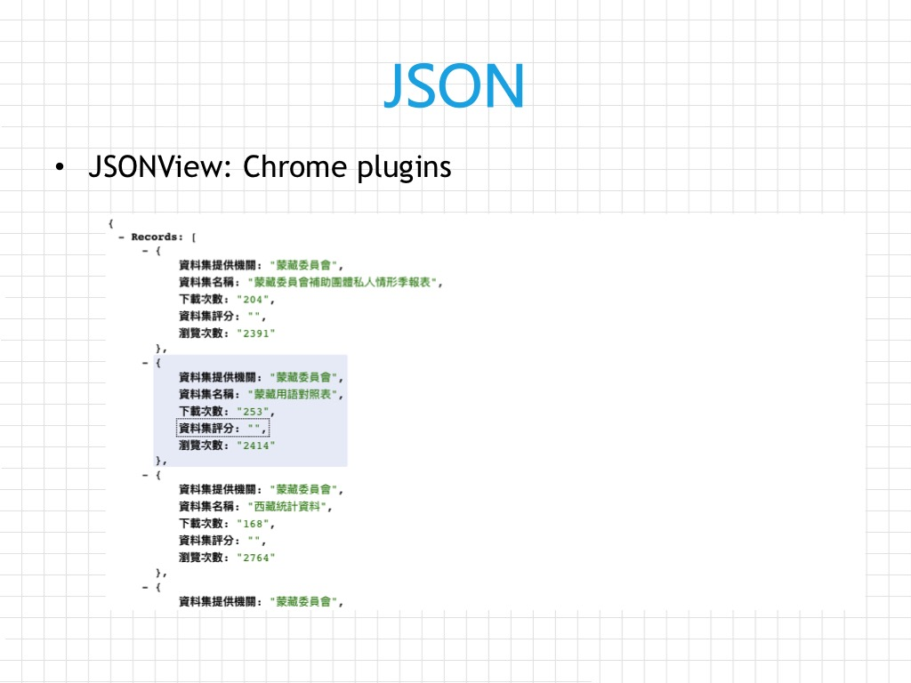

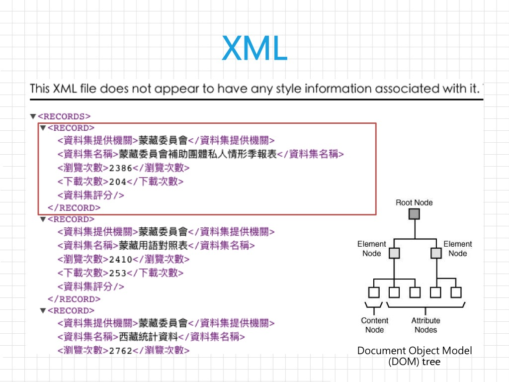

- Ex. [空氣品質即時污染指標](http://data.gov.tw/node/6074)

```r
# (1) .csv
url <- "http://data.gov.tw/iisi/logaccess/165?dataUrl=http://opendata.epa.gov.tw/ws/Data/AQX/?format=csv&ndctype=CSV&ndcnid=6074"
y <- read.csv(url, sep = ",", stringsAsFactors = F, header = T)

# (2) json files
library(jsonlite)
url <- 'http://data.gov.tw/iisi/logaccess/166?dataUrl=http://opendata.epa.gov.tw/ws/Data/AQX/?format=json&ndctype=JSON&ndcnid=6074'
y <- fromJSON(url, flatten = TRUE)
y <- as.data.frame(y$Records)

# (3) XML
library(XML)
url <- 'http://data.gov.tw/iisi/logaccess/167?dataUrl=http://opendata.epa.gov.tw/ws/Data/AQX/?format=xml&ndctype=XML&ndcnid=6074'
x <- xmlParse(url) # 以 xmlParse 解析 XML 檔案
xmlfiles <- xmlRoot(x) # 將 root 設定到 content 層級（一個偷吃步的做法）
y <- xmlToDataFrame(xmlfiles) # 轉換成 dataframe

# 將整理完成的檔案存成 CSV
write.csv(file = 'open.csv', y, fileEncoding = 'big5')
```

### OData

Open Data Protocol(OData)，它是一個開源的協定，藉由簡單的 URL 參數傳遞，來識別並查詢資料庫資料，此協定支援 XML 及 JSON 格式。

- [公共運輸整合資訊流通服務平台 Public Transport data eXchange](https://ptx.transportdata.tw/PTX)
- [Google MAP API](https://developers.google.com/maps/?hl=zh-tw)

# 2. 資料庫處理

### RSQLite

- DBI: R Database Interface
  - 提供一個簡便的資料庫介面讓 R User 可以處理超過記憶體容量的資料
- SQLite (Structured Query Language)
  - 是一個小型的關聯式資料庫系統，免費開源，使用時不需事先架設資料庫系統
  - 資料庫僅為單一個檔案，不論備份或搬移都很簡單，要跨平台也很方便
  - [SQL As Understood By SQLite](https://sqlite.org/lang_select.html)
  - [SQLite Tutorial](https://www.tutorialspoint.com/sqlite/index.htm)
  - [DB Browser for SQLite Portable](https://portableapps.com/apps/development/sqlite_database_browser_portable)

```sql
SELECT DISTINCT column_list
FROM table_list
  JOIN table ON join_condition
WHERE row_filter
ORDER BY column
LIMIT count OFFSET offset
GROUP BY column
HAVING group_filter;
```

- `install.packages(c("DBI", "RSQLite"))`
  - `vignette("RSQLite")`

### Issues

- 常見資料庫套件
  - [RJDBC: Oracle Database, MySql](https://cran.r-project.org/web/packages/RJDBC/index.html)
  - [RPostgreSQL: Postgres](https://cran.r-project.org/web/packages/RPostgreSQL/index.html)
- [Parameterized SQL queries](https://cran.r-project.org/web/packages/RODBCext/vignettes/Parameterized_SQL_queries.html)
  - [SQL injections: 隱碼攻擊](https://zh.wikipedia.org/wiki/SQL%E8%B3%87%E6%96%99%E9%9A%B1%E7%A2%BC%E6%94%BB%E6%93%8A)
  - Performance Tuning SQL Queries

# 3. 大「數據」(檔)的處理

### data.table

- fread 是 data.table 裡的 function
- 加快讀取速度 (真的很快！)
- [Introduction to the data.table package in R](http://datatable.r-forge.r-project.org/datatable-intro.pdf)

```r
library(data.table)
ubike <- fread(input = "./data/ubike-weather-big5.csv",
               data.table = FALSE,
               colClasses = c("factor","integer","integer","factor","factor",
                              "numeric","numeric","integer","numeric","integer",
                              "integer","numeric","numeric","integer","integer",
                              "numeric","numeric","numeric","numeric","numeric",
                              "numeric", "numeric","numeric"),
               stringsAsFactors = F)
```

### SparkR

Apache Spark 是一個開源叢集運算框架，最初是由加州大學柏克萊分校AMPLab所開發，使用記憶體內運算技術，能在資料尚未寫入硬碟時即在記憶體內分析運算。Spark在記憶體內執行程式的運算速度能做到比 Hadoop MapReduce 的運算速度快上100倍，即便是執行程式於硬碟時，Spark也能快上10倍速度，非常適合用於機器學習演算法。

- [SparkR Practice](http://rstudio-pubs-static.s3.amazonaws.com/133901_f42ea5e9eab74822a4985090748c232c.html)
- [一天上手 SparkR](http://dataology.blogspot.tw/2016/05/sparkr.html)

Thanks!  
Rafe C.H. Liu｜Contact｜[Linkedin](http://tw.linkedin.com/in/rafechliu)

UPDATE: 2017-12-01